# Bitcoin Project

Jeff Gould

4/16/2021

Script for pulling 5-minute candles from the CoinbasePro API, using the `rgdax` package. Only needs to be run once to get the data, unless we want finer candles.

```r
tictoc::tic()
for(Date in as.character(seq.Date(from = as.Date("2016-07-01"),
                       to = as.Date("2021-04-14"),
                       by = "1 day"))){
  temp_data <- rgdax::public_candles(product_id = "BTC-USD",
                                     start = glue::glue("{Date}T00:00:00.000000Z"),
                                     end = glue::glue("{as.Date(Date) + lubridate::days(1)}T00:00:00.000000Z"),
                                     granularity = 300)
  if(Date == "2016-07-01"){
    coinbase_candles_5M <- temp_data
  }else{
    coinbase_candles_5M <- dplyr::bind_rows(coinbase_candles_5M, temp_data)
  }
  Sys.sleep(.5) ## Pause is required so we don't max out API requests/5s periods

}
tictoc::toc()
write_csv(coinbase_candles_5M, "btcCandles5M.csv")
```

Now load the data and do some basic cleaning. I accidentally pulled the first candle of each day twice, as it’s the last candle of the previous day and the first candle of the day that it’s called. The `end` argument should have been 11:55:00, but oh well. Easy to clean up with a `distinct()`

```r
btcCandles <- read_csv("btcCandles5M.csv") %>% distinct()
```

General Formulas:

$r_t = \log(P_t) - \log(P_{t-1})$, where $r_t$ is the return and $P_t$ deontes the price at time $t$. General practice is to use the close of the candles.

$$Realized Variance = \sum_{t=1}^{n} r_t^2$$

Note that there are 288 candles in a day (24*60/5), so $n=288$ on most days. There are some days with fewer candles, due to outages or server maintenance. Let $k$ denote the number of missing candles. For these days, scale $RealizedVariance$ by $\frac{n-k}{n}$

$$Realized Vol (RV) = \sqrt{Realized Variance}$$

To annualize Variance:

$$AnnualizedRealVariance = 365 * RealizedVariance$$

$$AnnualizedRV = \sqrt{AnnualizedRealVariance}$$

For simplicity, I will simply calculate the Realized Variance/Volatility for a single day, instead of on a 24-hour rolling basis. We can revisit this later. But if we simply forecast at the start of each day, I think this method will be sufficient.

Also, there is an erroneous candle on `2017-04-15 23:00:00`, where after an outage the open price is 0.06. I remove that candle for now with `filter(open >1)`. Also remove days with fewer than 250 candles for now.

```r
btcRV <- btcCandles %>%
  filter(open >1) %>%
  mutate(Date =  lubridate::date(time),
         Return = case_when(
           row_number() == 1 ~ log(close) - log(open),
           TRUE ~log(close) - log(lag(close))
           )) %>%
  group_by(Date) %>%
  mutate(RealizedVariance = sum(Return^2) * n()/288,
         RV = sqrt(RealizedVariance),
         AnnualizedVariance = 365 * RealizedVariance,
         AnnualizedRV = sqrt(AnnualizedVariance),
         TotalVolume = sum(volume),
         candles = n()) %>%
  filter(candles > 250)
```

And some quick visualizations, looking at just the opening candles for each day.

As expected, RV looks to follow an Inverse Gamma distribution

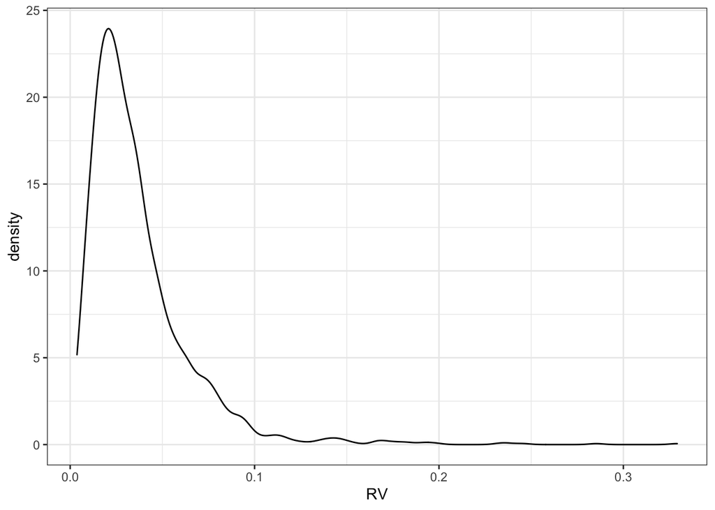

```r
# btcRV_open <- btcRV %>%
#   slice_min(order_by = time, n = 1) %>%
#   ungroup()

btcRV_open <- btcRV %>%
  filter(lubridate::hour(time) == 0, lubridate::minute(time) == 0) %>%
  ungroup()

ggplot(btcRV_open) +
  geom_density(aes(x = RV)) +
  theme_bw()
```

There looks to be a modest correlation between Realized Volatility in period $t$ and $t-1$

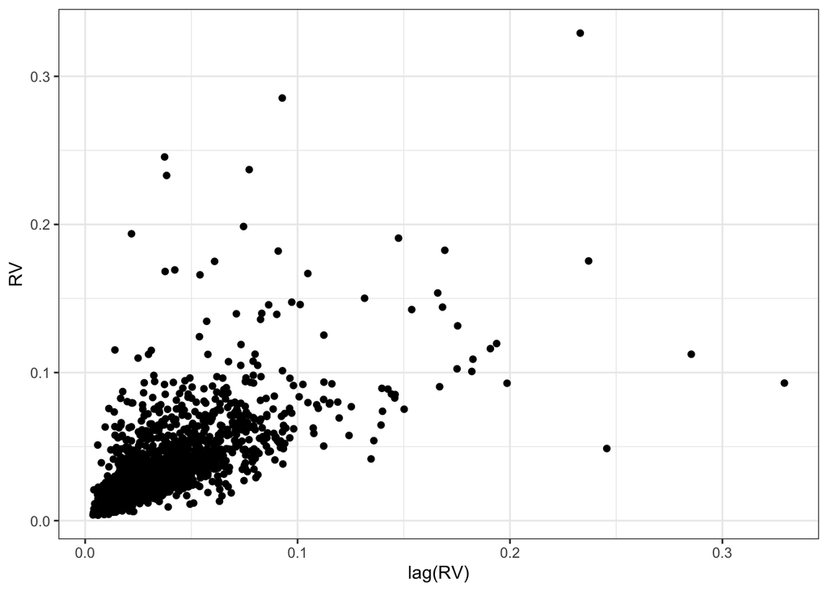

```r
ggplot(data = btcRV_open, aes(x = lag(RV), y = RV)) +
  geom_point() +
  theme_bw()
```

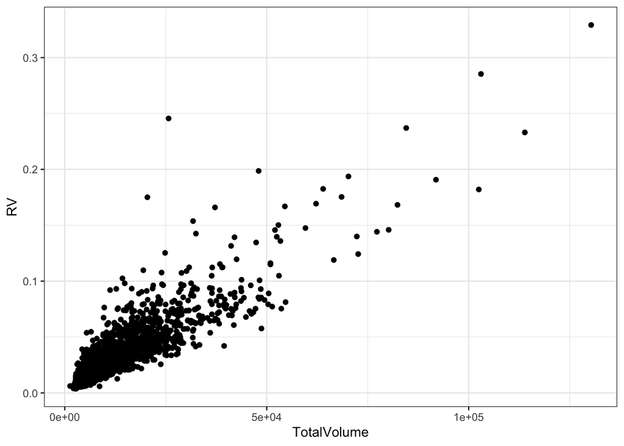

```r
ggplot(data = btcRV_open) +
  geom_point(aes(x = TotalVolume, y = RV)) +
  theme_bw()
```

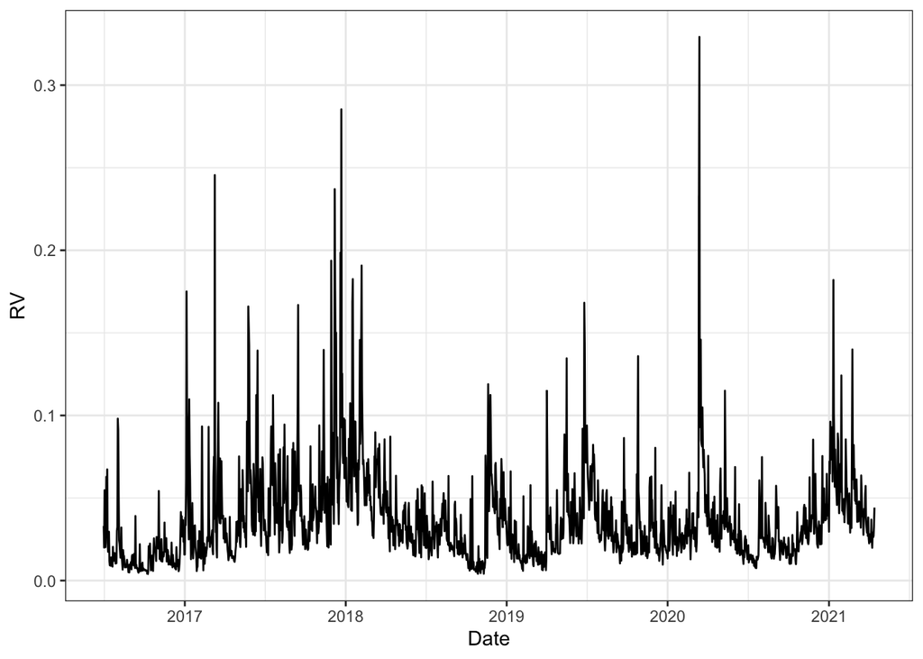

```r
ggplot(data = btcRV_open) +
  geom_line(aes(x = Date, y = RV)) +
  theme_bw()
```

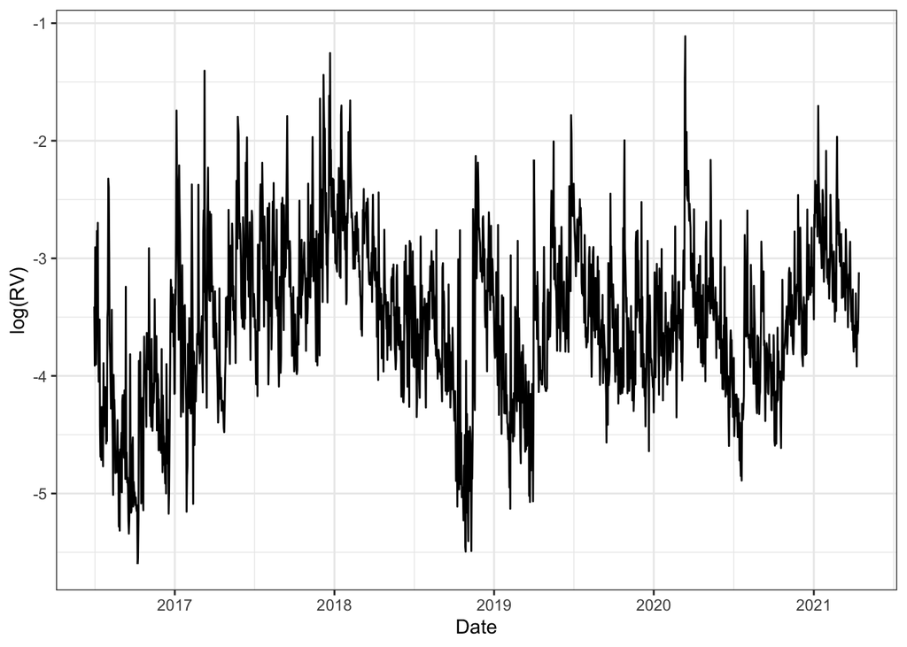

```r
ggplot(data = btcRV_open) +
  geom_line(aes(x = Date, y = log(RV))) +
  theme_bw()
```

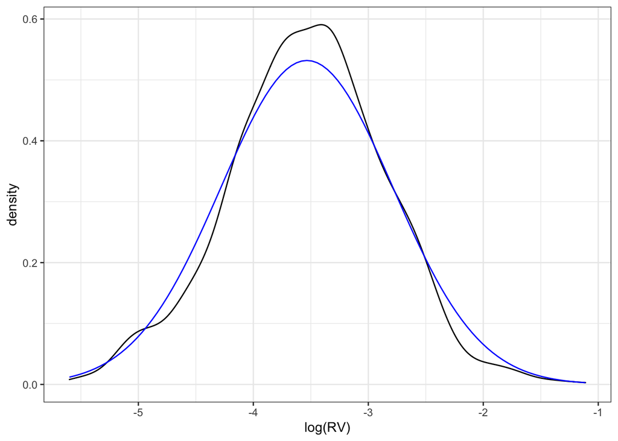

```r
ggplot(data = btcRV_open) +
  geom_density(aes(x = log(RV))) +
  stat_function(fun = dnorm, args = list(mean = -3.534, sd = 0.75), col = "blue") +
  theme_bw()
```

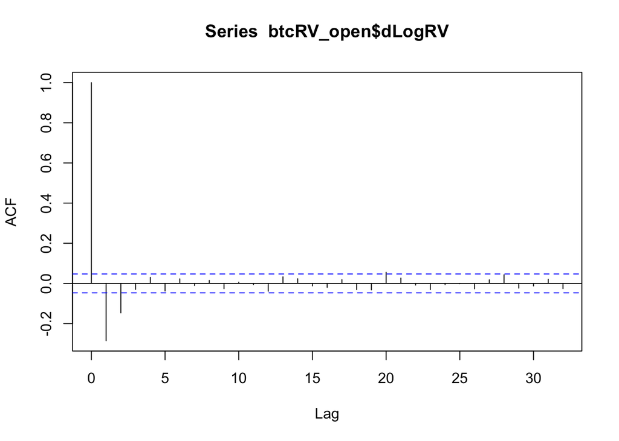

```r
btcRV_open <- btcRV_open %>% mutate(dLogRV = log(RV) - log(lag(RV)))
btcRV_open$dLogRV[1] = 0
acf(btcRV_open$dLogRV)
```

```r
#write_csv(btcRV_open, "btcOpenCandles.csv")
```

Realized Vol as a stochastic process:

$$d\sigma^2(t) = - \lambda \sigma^2(t) dt + dz(\lambda t) \,\,\, \lambda > 0$$

Define $\phi = 1 - \lambda$ and $\mu_{t+1} = z(\lambda (t+1)) - z(\lambda z)$

We get

$$\log \sigma^2_t = (1 - \phi)\mu + \phi \log \sigma^2_{t-1} \epsilon_t$$